# Взаимосвязь количества бракоразводных процессов и пожаров в Москве в 2015-2016 годах

Титков Даниил

**Веб-версию можно посмотреть [здесь](https://danieltitkov.github.io/r-fun-things/Report/Fires-Divorce_Report_Output.html)**

## Введение

Ученые почти единогласны в том, что свадьба и развод оказывают сильное влияние на психологическое состояние человека и в большинстве случаев оказываются сильнейшим стрессом, даже если оцениваются (в случае свадьбы) как радостные события (Carr and Wolchik 2015; Rudd, Holtzworth-Munroe, and Rossi 2016). Это согласуется с житейскими представлениями об этом вопросе.

Между тем, в средствах массовой информации многократно сообщалось о поджогах, связанных со свадьбами ([1](https://russia.tv/video/show/brand_id/5169/episode_id/1053399/video_id/1042726/), [2](http://www.vesti.ru/doc.html?id=1901157&cid=520), [3](http://obozrevatel.com/family/v-britanii-zhenih-podzheg-drevnij-zamok-vo-vremya-svadbyi.htm)) и разводами ([1](http://www.e1.ru/news/spool/news_id-449260.html), [2](http://skoronovosti.ru/nnovgorod/2016/09/01/247046-nizhegorodets-podzheg-mashinu-zheny-za-zhelanie-razvestis.html), [3](http://petrowsk64.ru/posle-razvoda-zhitel-petrovska-podzheg-dom-byivshey-zhenyi.html), [4](http://www.mk.ru/incident/2015/05/19/podrostok-podzheg-kvartiru-chtoby-otomstit-novomu-otcu-za-razvod-roditeley.html), [5](http://v-kurse-voronezh.ru/proishestvia/21357)). Ввиду этого обстоятельства автор исследования задался вопросом, являются ли свадьбы и разводы существенными факторами возникновения пожаров.

## Гипотеза

Было сделано *обоснованное предположение*, что количество пожаров взаимосвязано с числом браков и разводов.

## Данные

Для проверки гипотезы исследования было решено обратиться к открытым данным. Данные были взяты с [Портала открытых данных Правительства Москвы](http://data.mos.ru/). Для исследования использовались следующие наборы данных:

1. Число браков по годам и месяцам. Данные доступны по [ссылке](http://data.mos.ru/opendata/7704111479-chislo-brakov-po-godam). Всего в данных содержится 80 наблюдений за период с января 2010г. по август 2016г.
2. Число разводов по годам и месяцам. Данные доступны по [ссылке](http://data.mos.ru/opendata/7704111479-chislo-razvodov-po-godam). Всего в данных содержится 80 наблюдений за период с января 2010г. по август 2016г.
3. Данные вызовов подразделений пожарно-спасательного гарнизона города Москвы по месяцам. Данные доступны по [ссылке](http://data.mos.ru/opendata/7710474791-dannye-vyzovov-pojarnoy-slujby-po-mesyatsam). Число вызовов пожарно-спасательных бригад было принято за показатель числа пожаров. Всего в данных содержится 19 наблюдений за период с января 2015г. по июль 2016г.

Так как информация по вызовом пожарных бригад имеется только за 2015 и 2016 год, были отобраны наблюдения по бракам и разводам за эти года, после чего данные были сведены в одну таблицу, с которой и проводилась дальнейшая работа.

Таблица 1. Данные по пожарам и разводам в 2015-2016 годах

| Year | Month | Marriages | Divorces | Fires |
| --- | --- | --- | --- | --- |
| 2015 | январь | 4983 | 3344 | 4689 |
| 2015 | февраль | 5807 | 2860 | 2535 |
| 2015 | март | 4890 | 3881 | 6092 |
| 2015 | апрель | 8653 | 3928 | 7671 |
| 2015 | май | 5482 | 3324 | 3568 |
| 2015 | июнь | 10150 | 3454 | 4351 |
| 2015 | июль | 12550 | 3876 | 4403 |
| 2015 | август | 12495 | 3341 | 4569 |
| 2015 | сентябрь | 11515 | 3800 | 4674 |
| 2015 | октябрь | 9164 | 3946 | 4972 |
| 2015 | ноябрь | 6566 | 3457 | 4536 |
| 2015 | декабрь | 7465 | 4349 | 4313 |
| 2016 | январь | 4332 | 3133 | 5043 |
| 2016 | февраль | 4944 | 2967 | 4218 |
| 2016 | март | 5279 | 4037 | 4708 |
| 2016 | апрель | 5256 | 3854 | 5884 |
| 2016 | май | 4712 | 3609 | 5478 |
| 2016 | июнь | 10636 | 3459 | 4630 |
| 2016 | июль | 12289 | 3560 | 4601 |

## Метод

Для выявления взаимосвязи между переменными, представленными в количественных шкалах, было решено использовать коэффициент корреляции, *потому что вечное не устаревает*. В силу небольшого числа наблюдений был выбран коэффициент коллеряции Спирмена.

В процессе работы использовался язык R версии 3.2.4, а также следующие дополнения (пакеты): dplyr, tidyr, ggplot2, psych, ggthemes. Не обошлось и без источника вдохновения[^1].

## Анализ

Была получена следующая матрица корреляций:

Таблица 2. Корреляции браков, разводов и пожаров.

|  | Marriages | Divorces | Fires |
| --- | --- | --- | --- |
| Marriages | 1.0000000 | 0.1859649 | -0.3122807 |
| Divorces | 0.1859649 | 1.0000000 | 0.4877193 |
| Fires | -0.3122807 | 0.4877193 | 1.0000000 |

Корреляциям соответствуют следующие уровни значимости:

Таблица 3. Уровни значимости корреляций.

|  | Marriages | Divorces | Fires |
| --- | --- | --- | --- |
| Marriages | 0.0000000 | 0.4459063 | 0.1930425 |
| Divorces | 0.4459063 | 0.0000000 | 0.0341506 |
| Fires | 0.1930425 | 0.0341506 | 0.0000000 |

Нетрудно видеть, что корреляция между числом разводов и числом пожаров значима на уровне p < 0.05 (p = 0.034), следовательно, можно сделать предположение, что существует взаимосвязь между числом разводов и числом пожаров в Москве в течение исследуемого периода (январь 2015г. - июль 2016г.).

Выявленную взаимосвязь также *весьма убедительно* отражает график.

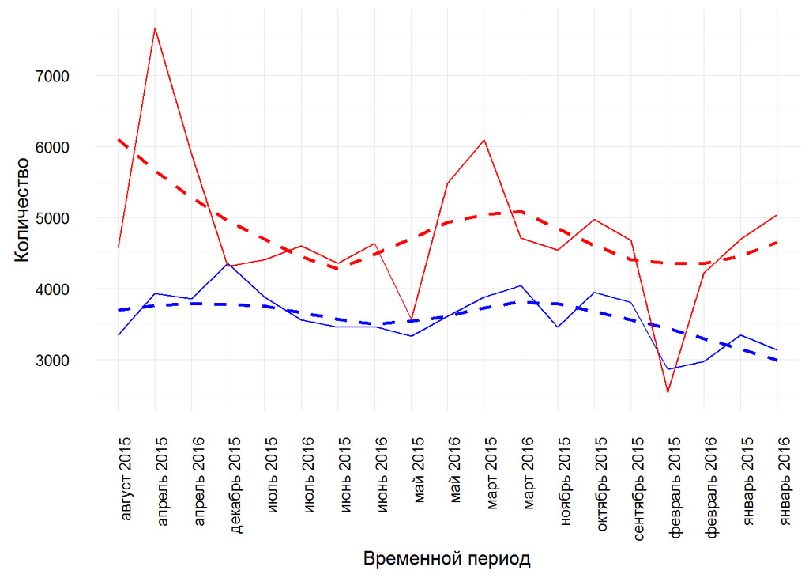

Рисунок 1. Синими линиями отображены данные по разводам, красными - по пожарам. Пунктирными линиями отображены приближения, полученные методом локальной регрессии (locally weighted scatterplot smoothing).

О наличии взаимосвязи также говорит угол наклона регрессионных прямых, что можно видеть на диаграмме рассеивания.

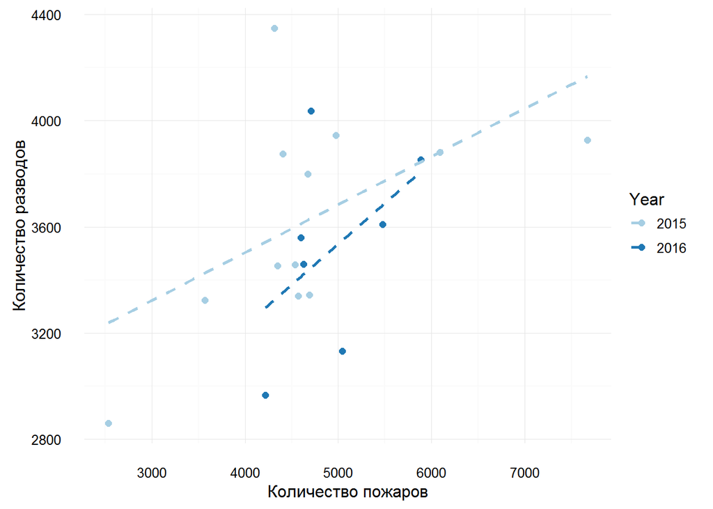

Рисунок 2. Пунктирными линиями отображены приближения, полученные методом линейной регрессии.

## Обсуждение результатов

Полученные результаты трудно объяснить однозначно. Тем не менее, они дают *серьезные* основания для дальнейших исследований в данной области. В частности, хорошим решением будет провести аналогичные исследования на данных других городов России и мира, а также обратиться в архивы и получить данные за прошлые года и десятилетия (а если повезет, то и века). Возможно, разводы действительно являются существенным фактором возникновения пожаров, хотя возможно, что взаимосвязь обусловлена влиянием неучтенных переменных. Для науки очень важно это выяснить.

## Выводы

1. Существует статистически достоверная взаимосвязь между числов разводов и пожаров в городе Москве за период с января 2015 до июля 2016 года.
2. Не выявлено взаимосвязи между числом браков и пожаров в городе Москве за рассматриваемый период.

## Заключение

Женитесь на правильных людях. Любите друга друга. Не играйте с огнём. ^_^

## Библиография

Carr, Colleen M., and Sharlene A. Wolchik. 2015. “Marital Status, Divorce, and Child Development.” In *International Encyclopedia of the Social & Behavioral Sciences (Second Edition)*, edited by James D. Wright, Second Edition, 518–24. Oxford: Elsevier. doi:http://dx.doi.org/10.1016/B978-0-08-097086-8.23222-4.

Rudd, B.N., A. Holtzworth-Munroe, and F.S. Rossi. 2016. “Divorce and Parental Separation.” In *Encyclopedia of Mental Health (Second Edition)*, edited by Howard S. Friedman, Second Edition, 79–87. Oxford: Academic Press. doi:http://dx.doi.org/10.1016/B978-0-12-397045-9.00177-4.

[^1]: [Вдохновение](http://www.tylervigen.com/spurious-correlations)